# Week 8: Digital Twinning & Calibration

EE0849 Introduction to Robotics

Basri Erdogan

# Part 1: The Reality Gap

## From Simulation to Reality

**In Simulation (Python)**

- Perfect geometry
- No friction or backlash
- Instant, exact motion
- Mathematical precision

```python
# Perfect forward kinematics
T = robot.fkine(q)
# Returns exact pose
```

**In Reality (FANUC)**

- Manufacturing tolerances
- Gear backlash & friction
- Servo lag & overshoot
- Mechanical deflection

The robot *almost* goes where you command…

## The Digital Twin Concept

[figure not shown]

## Why Does This Matter?

**Scenario**: You calculate joint angles in Python to reach a target

| Step | Expected | Reality |
| --- | --- | --- |
| Python IK output | q = [10°, 45°, -30°, 0°, 60°, 0°] | Same |
| Command to FANUC | Same angles | Same |
| Actual joint position | Same | Close (±0.01°) |
| Actual TCP position | (400, 200, 300) mm | (399.2, 200.8, 299.5) mm |

# Part 2: Accuracy vs Repeatability

## Definitions

**Accuracy**

How close the robot gets to the *commanded* position

$$\text{Accuracy} = |P_{actual} - P_{commanded}|$$

- Affected by calibration
- Can be improved
- Typically ±0.5 to ±2 mm

**Repeatability**

How consistently the robot returns to the *same* position

$$\text{Repeatability} = \sigma(P_{measurements})$$

- Inherent to mechanism
- Hard to improve
- Typically ±0.02 to ±0.1 mm

## Visual Comparison

[figure not shown]

## Why Repeatability > Accuracy

For most industrial robots:

| Specification | Typical Value |
| --- | --- |
| Repeatability | ±0.02 - ±0.08 mm |
| Accuracy | ±0.5 - ±2.0 mm |

**Tip**

**Repeatability is 10-100x better than accuracy!** This is the most important specification to understand for industrial robotics.

This is why industrial robots:

- Use **taught positions** (move to point, record)
- Don’t rely on calculated positions for precision
- Need calibration for offline programming

## Industrial Approach

**Online Teaching** (Repeatability)

1. Jog robot to position
2. Record actual joint values
3. Robot returns to *same* joint values
4. Exploits repeatability

Used for: Pick-and-place, welding fixtures

**Offline Programming** (Accuracy)

1. Calculate positions from CAD
2. Convert to joint angles
3. Robot goes to *calculated* position
4. Depends on accuracy

Used for: Large parts, complex paths

# Part 3: Sources of Error

## Error Categories

[figure not shown]

## 1. Geometric Errors

**Manufacturing tolerances in robot structure**

| Parameter | Nominal | Tolerance |
| --- | --- | --- |
| Link length | 400.00 mm | ±0.05 mm |
| Joint offset | 0.00° | ±0.01° |
| Joint axis alignment | Perpendicular | ±0.02° |

These errors are **constant** and can be calibrated out.

## 2. Gear Backlash

**What is it?**

“Play” between gear teeth when changing direction

**Effect:**

- Position depends on approach direction
- Different position going CW vs CCW
- Typical backlash: 0.5-2 arc-minutes

**Mitigation:**

- Always approach from same direction
- Use spring preload
- Accept the error for non-critical moves

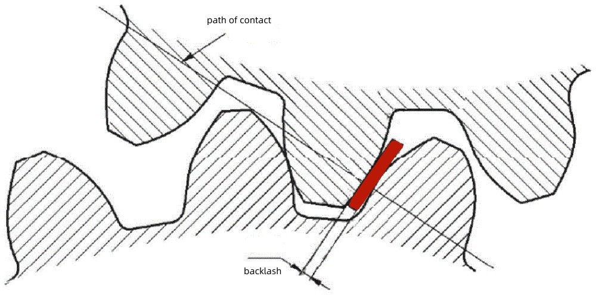

## 3. Compliance (Deflection)

**Structural Deflection**

Robot arm bends under:

- Its own weight
- Payload weight
- Process forces (pushing, welding)

$$\delta = \frac{F \cdot L^3}{3EI}$$

- $\delta$ — tip deflection, $F$ — applied force
- $L$ — length, $E$ — elastic modulus, $I$ — moment of inertia

[figure not shown]

**Characteristics:**

- Pose-dependent (worst at full extension)
- Load-dependent
- Can be 0.5-3 mm at full reach

## 4. Thermal Effects

**Temperature changes cause expansion**

$$\Delta L = L \cdot \alpha \cdot \Delta T$$

| Material | α (×10⁻⁶/°C) |
| --- | --- |
| Steel | 12 |
| Aluminum | 23 |

**Example**: 1 m aluminum link, 10°C rise:
$$\Delta L = 1000 \times 23 \times 10^{-6} \times 10 = 0.23 \text{ mm}$$

**Mitigation**: Warm up robot before precision work

## 5. Servo Errors

**Control system limitations**

- Following error during motion
- Settling time at stop
- Servo stiffness (gain)

**FANUC specifications:**

- Position loop gain: Adjustable
- Settling time: ~50-100 ms for FINE
- Following error: Depends on speed

## Error Summary

| Error Source | Magnitude | Correctable? |
| --- | --- | --- |
| Geometric (link lengths) | 0.1-1 mm | Yes (calibration) |
| Gear backlash | 0.05-0.2 mm | Partial |
| Compliance | 0.5-3 mm | Yes (compensation) |
| Thermal | 0.1-0.5 mm | Yes (warm-up) |
| Servo | 0.01-0.1 mm | Yes (tuning) |

# Part 4: Calibration Methods

## What is Calibration?

**Finding the true robot parameters**

The robot has a *nominal* kinematic model (from CAD)

Calibration finds the *actual* parameters:

- True link lengths
- True joint offsets
- True axis alignments

## Calibration Approaches

[figure not shown]

## Mastering (Joint Zero Calibration)

**Purpose**: Define the “zero” position for each joint

**Process:**

1. Move joint to mechanical reference (mark, pin)
2. Tell controller “this is zero”
3. Repeat for all joints

**When needed:**

- After motor/encoder replacement
- After collision
- When positions drift significantly

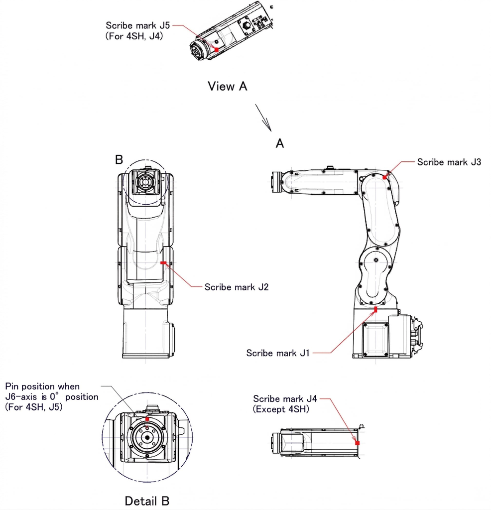

Zero-position scribe marks on FANUC LR Mate 200iD (B-83574EN, Fig. 8.3a)

## FANUC Mastering Methods (B-83574EN, Ch. 8)

| Menu Item | What You Do | When to Use |
| --- | --- | --- |
| **1 — Fixture position** | Align joints with precision jig | Motor/reducer replaced, disassembly |
| **2 — Zero-position** | Jog all axes to 0° using scribe marks | Quick-fix after failure (visual, less accurate) |
| **3 — Quick master** | Jog to saved reference pose, or use last power-off pose | BZAL alarm, battery died (no parts changed) |
| **5 — Single-axis** | Re-master one joint only | Single axis service or cable disconnect |

Quick master has two sub-modes:

- **At reference position**: jog to saved pose (default: 0° on all axes)
- **Using power off position**: no jogging — uses last known pose

## TCP Calibration (4-Point Method)

**Goal**: Find true Tool Center Point location

1. Mount tool on robot
2. Define a fixed point in space (pin tip)
3. Touch point from 4+ different orientations
4. System calculates TCP offset

**Math:** All poses → same world point: $T_{tcp}^{0} = T_{flange}^{0} \cdot T_{tcp}^{flange}$

[figure not shown]

## TCP Calibration Methods Compared

| Method | Points | Finds | Trade-off |
| --- | --- | --- | --- |
| **3-Point** | 3 orientations | XYZ position | Exact (3 eqns, 3 unknowns) — no way to detect a bad touch |
| **4-Point** | 4+ orientations | XYZ position | Over-constrained → reports **residual error**; redo if too high |
| **6-Point** | 4 + 2 orient. | XYZ + orientation | Extra 2 pts define tool Z & X axes |

- **Why 4 over 3?** Over-constraining lets the controller flag inaccurate touches
- **Why 6?** Welding torches, dispensing needles — any tool where approach direction matters

## User Frame Calibration (3-Point Method)

**Goal**: Define a coordinate system aligned with fixture/workpiece

**Process:**

1. **Origin point**: Touch corner of fixture
2. **X-direction point**: Touch point along X axis
3. **Y-plane point**: Touch point in XY plane

The controller calculates the transform from World to User frame.

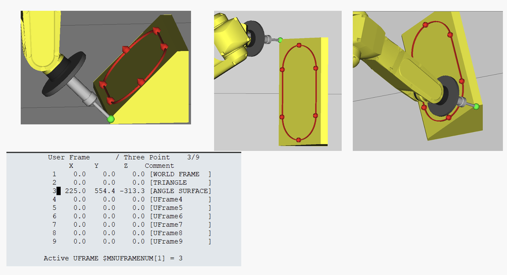

3-point user frame teaching in Roboguide — touching fixture points from different orientations

## Full Kinematic Calibration

**For high-accuracy applications**

**Process:**

1. Measure TCP position at many poses (50-100+)
2. Use external measurement system (laser tracker, CMM)
3. Solve for all kinematic parameters
4. Update robot model

**Achieves**: Sub-millimeter accuracy

**Cost**: Expensive equipment, significant time

# Part 5: FANUC World Zones & Limits

## Why Limit Robot Motion?

**Safety and protection:**

- Keep robot away from fixtures
- Prevent collisions with environment
- Protect cables and hoses
- Define safe working areas

## Joint Limits (Soft Limits)

**Software limits on each joint**

| Joint | Lower Limit | Upper Limit |
| --- | --- | --- |
| J1 | -170° | +170° |
| J2 | -135° | +70° |
| J3 | -80° | +270° |
| J4 | -190° | +190° |
| J5 | -125° | +125° |
| J6 | -360° | +360° |

These are *software* limits - can be adjusted within *hardware* limits.

## Cartesian Limits (World Zones)

[figure not shown]

## World Zone Types

**FANUC provides several zone types:**

| Type | Function | Action |
| --- | --- | --- |
| Position Register Interference | Avoid specific position | Stop or error |
| Cartesian Space Interference | Avoid 3D region | Stop or signal |
| Safe Zone | Must stay inside | Stop if exit |
| Forbidden Zone | Must stay outside | Stop if enter |

## Setting Up a World Zone

**Example: Forbidden Zone around fixture**

```
MENU → SETUP → Frames → Space → Interference
Zone 1:
  Type: Cartesian
  Shape: Box
  X: 400 to 600 mm
  Y: -100 to 100 mm
  Z: 0 to 200 mm
  Action: Stop + Signal DO[10]
```

## Interference Checking

**How it works:**

1. Robot calculates future TCP path
2. Checks path against defined zones
3. If violation predicted:
   - Stops motion (FINE termination)
   - Sets output signal
   - Displays error

**Warning**

**Checks TCP position only, not the full arm envelope!** The elbow can still collide even if the TCP stays outside a forbidden zone.

# Part 6: The Digital Twin (Concept)

## What is a Digital Twin?

**A virtual replica of the physical robot**

- Same kinematics (DH model)
- Same joint limits
- Same tool definition

**FANUC Roboguide** is our digital twin environment:

- Offline programming (no production downtime)
- Collision checking before running
- Path optimization in simulation
- Training operators without hardware risk

[figure not shown]

[figure not shown]

FANUC Roboguide — offline programming environment

**Key insight:** The digital twin (Roboguide) is only as good as its calibration. This is why we study accuracy, error sources, and calibration methods.

# Part 7: Advanced TP Programming

## Position Registers (PR[ ])

**Stored Cartesian poses that programs can reference and modify**

```
! Store current position
PR[1]=LPOS ;

! Move to a position register
L PR[1] 500mm/sec FINE ;

! Access individual components
PR[1,1]=400.0 ;   ! Set X
PR[1,2]=100.0 ;   ! Set Y
PR[1,3]=250.0 ;   ! Set Z
PR[1,4]=180.0 ;   ! Set W (Rx)
PR[1,5]=0.0 ;     ! Set P (Ry)
PR[1,6]=0.0 ;     ! Set R (Rz)
```

**Why use PR instead of P?**

- P[ ] positions are local to one program
- PR[ ] are global — shared across all programs
- PR[ ] can be modified with math at runtime

## Offset Positions

**Computing new positions from existing ones**

```
! Approach: 50mm above the pick point
PR[2]=PR[1] ;
PR[2,3]=PR[1,3]+50.0 ;   ! Z + 50mm

! Move sequence with approach
L PR[2] 500mm/sec FINE ;  ! Approach
L PR[1] 100mm/sec FINE ;  ! Pick
CALL HAND_CLOSE ;
L PR[2] 500mm/sec FINE ;  ! Retract
```

**Common offset patterns:**

| Pattern | Offset |
| --- | --- |
| Approach from above | Z + height |
| Retract after place | Z + height |
| Shift along conveyor | X + distance |
| Pallet column offset | Y + pitch |

## The Offset Instruction

**FANUC’s built-in offset command**

```
! Move to P[1] with an offset stored in PR[5]
L P[1] 500mm/sec FINE Offset,PR[5] ;
```

The robot moves to P[1] shifted by the XYZ values in PR[5].

**Example: Approach and retract pattern**

```
! Define approach offset (50mm above)
PR[10,1]=0 ;
PR[10,2]=0 ;
PR[10,3]=50.0 ;

! Approach → Pick → Retract
L P[1] 500mm/sec FINE Offset,PR[10] ;
L P[1] 100mm/sec FINE ;
CALL HAND_CLOSE ;
L P[1] 500mm/sec FINE Offset,PR[10] ;
```

## User Frames (UFRAME)

**Problem:** If the workstation moves, all taught points become wrong.

**Solution:** Teach points relative to a User Frame attached to the fixture.

**If the fixture moves:**

- Re-calibrate the same User Frame (3 points)
- All taught positions update automatically
- For two known positions: pre-calibrate UF[1] and UF[2], switch with `UFRAME_NUM`

```
UFRAME_NUM=1 ;   ! Select User Frame 1
! All subsequent moves are in
! this frame's coordinates
```

Positions taught in one UF cannot be used with a different UF — frame mismatch error!

[figure not shown]

## Setting Up a User Frame (3-Point Method)

**Three points define the frame:**

1. **Origin Point** — corner of fixture
2. **X-Direction Point** — along the X edge
3. **Y-Plane Point** — roughly along Y (defines the XY plane)

```
MENU → SETUP → Frames → User Frame
Frame Number: 1
  Method: Three Point
  Orient Origin Point: [Record]
  X Direction Point:   [Record]
  Y Direction Point:   [Record]
```

The controller computes the full $T_{User}^{World}$ transform automatically.

## Tool Frames (UTOOL)

**Defines where the Tool Center Point (TCP) is**

- Relative to the flange
- All Cartesian moves reference TCP
- Different tools = different UTOOLs

```
UTOOL_NUM=1 ;   ! Select Tool 1
! TCP is now at the tool tip
```

**Why it matters:**

- Without correct UTOOL, linear moves curve
- Orientation changes pivot around wrong point
- Calibrate with 4-point or 6-point method

[figure not shown]

## Multi-Program Architecture

**Real applications use multiple programs calling each other**

```
/PROG MAIN
   1: UFRAME_NUM=1 ;
   2: UTOOL_NUM=1 ;
   3: LBL[1] ;
   4: CALL PICK ;
   5: CALL PLACE ;
   6: JMP LBL[1] ;
/END

/PROG PICK
   1: J P[1:Pick_App] 100% FINE ;
   2: L P[2:Pick] 100mm/sec FINE ;
   3: CALL HAND_CLOSE ;
   4: L P[1:Pick_App] 500mm/sec FINE ;
/END

/PROG PLACE
   1: J P[1:Place_App] 100% FINE ;
   2: L P[2:Place] 100mm/sec FINE ;
   3: CALL HAND_OPEN ;
   4: L P[1:Place_App] 500mm/sec FINE ;
/END
```

## Simple Palletizing with Offsets

**Placing parts in a grid pattern using math**

```
/PROG PALLETIZE
   1: R[1]=0 ;               ! Part counter
   2: LBL[1] ;
   3: CALL PICK ;
   4: ! Calculate column and row
   5: R[2]=R[1] MOD 4 ;      ! Column (0-3)
   6: R[3]=R[1] DIV 4 ;      ! Row (0-2)
   7: ! Build offset
   8: PR[10,1]=R[2]*50.0 ;   ! X = col * 50mm pitch
   9: PR[10,2]=R[3]*50.0 ;   ! Y = row * 50mm pitch
  10: PR[10,3]=0 ;
  11: ! Place with offset
  12: L P[5:Pallet_Origin] 500mm/sec FINE Offset,PR[10] ;
  13: CALL HAND_OPEN ;
  14: R[1]=R[1]+1 ;
  16: IF R[1]<12, JMP LBL[1] ;  ! 4x3 = 12 parts
/END
```

# Summary

## Key Takeaways

1. **Repeatability >> Accuracy** for industrial robots
   - Teach positions when possible
   - Calibrate for offline programming
2. **Error sources are multiple**
   - Geometric, backlash, compliance, thermal, servo
   - Some correctable, some inherent
3. **Calibration improves accuracy**
   - Mastering: joint zeros
   - TCP calibration: tool offset
   - User frame calibration: fixture alignment
4. **Advanced TP programming enables flexible automation**
   - Position registers and offsets avoid re-teaching
   - User frames make programs portable
   - Multi-program architecture keeps code organized

## Next Week

**Week 9: Mobile Robot Kinematics**

- Holonomic vs Non-holonomic constraints
- Unicycle model
- Bicycle model (Ackermann steering)
- Lab 8: Driving a mobile robot in simulation

## Exit Ticket

**Scenario:** You have a pick-and-place station. The pick point is at P[1]. You need to:

1. Approach from 40mm above P[1]
2. Pick the part (CALL HAND_CLOSE)
3. Place it at a position that is 200mm to the right (+X) of P[1], at the same height

Write the TP code using Position Registers and offsets. Assume UFRAME and UTOOL are already set.

## Exit Ticket: Solution

```
! Define approach offset
PR[10,1]=0 ; PR[10,2]=0 ; PR[10,3]=40.0 ;
! Define place offset
PR[11,1]=200.0 ; PR[11,2]=0 ; PR[11,3]=0 ;

! Approach pick
L P[1] 500mm/sec FINE Offset,PR[10] ;
! Pick
L P[1] 100mm/sec FINE ;
CALL HAND_CLOSE ;
! Retract
L P[1] 500mm/sec FINE Offset,PR[10] ;
! Approach place (combine offsets via PR math)
PR[12]=P[1] ;
PR[12,1]=PR[12,1]+200.0 ;
L PR[12] 500mm/sec FINE Offset,PR[10] ;
! Place
L PR[12] 100mm/sec FINE ;
CALL HAND_OPEN ;
! Retract
L PR[12] 500mm/sec FINE Offset,PR[10] ;
```

# Questions?

Contact: b.erdogan@iku.edu.tr